# *S. pneumoniae* strain invasiveness

## Description and filtering of the dataset

As many of these serotypes are rare, to facilitate model fitting, we exclude any serotype for which the maximum number of observations is below five, and any serotype found in fewer than five strains, and any strain associated with fewer than five serotypes:

## Fitting the statistical models

An adjusted type-specific Poisson model can be applied to the data using only classification by serotype (**adjusted serotype-specific Poisson** model):

$$d_{i,j,k} \sim Poisson(\delta_{i}\nu_{j}\rho_{i,j,k}N_{i}t_{i})$$

We can alternatively fit a negative binomial version of the same model:

$$d_{i,j,k} \sim NegBin(\delta_{i}\nu_{j}\rho_{i,j,k}N_{i}t_{i})$$

An adjusted type-specific Poisson model can alternatively be applied to the data using only classification by strain (**adjusted strain-specific Poisson** model):

$$d_{i,j,k} \sim Poisson(\delta_{i}\nu_{k}\rho_{i,j,k}N_{i}t_{i})$$

We can also fit a negative binomial equivalent (**adjusted strain-specific negative binomial** model):

$$d_{i,j,k} \sim NegBin(\delta_{i}\nu_{k}\rho_{i,j,k}N_{i}t_{i})$$

Models can also combine serotype and strain information, with **invasiveness primarily determined by serotype, and modified by strain**:

$$d_{i,j,k} \sim Poisson(\delta_{i}\nu_{k}\nu_{k}\rho_{i,j,k}N_{i}t_{i})$$

This can also be applied using a negative binomial distribution:

$$d_{i,j,k} \sim NegBin(\delta_{i}\nu_{k}\nu_{k}\rho_{i,j,k}N_{i}t_{i})$$

Models can alternative have **invasiveness primarily determined by strain, and modified by serotype**:

$$d_{i,j,k} \sim Poisson(\delta_{i}\nu_{k}\nu_{k}\rho_{i,j,k}N_{i}t_{i})$$

This model can also be applied using a negative binomial model:

$$d_{i,j,k} \sim NegBin(\delta_{i}\nu_{k}\nu_{k}\rho_{i,j,k}N_{i}t_{i})$$

The final model structure assigns a **different invasiveness to each strain-serotype combination**:

$$d_{i,j,k} \sim Poisson(\delta_{i}\nu_{j,k}\rho_{i,j,k}N_{i}t_{i})$$

A version using the negative binomial distribution can also be fitted:

$$d_{i,j,k} \sim NegBin(\delta_{i}\nu_{j,k}\rho_{i,j,k}N_{i}t_{i})$$

To check the models have fitted correctly, we can plot the $\hat{R}$ values across MCMCs:

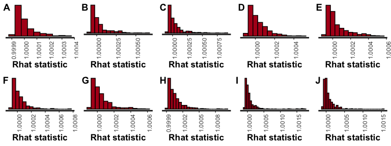

```r
fit_list <- list(adjusted_serotype_specific_poisson_fit,
                                  adjusted_serotype_specific_negbin_fit,
                                  adjusted_strain_specific_poisson_fit,
                                  adjusted_strain_specific_negbin_fit,
                                  adjusted_serotype_specific_strain_modified_poisson_fit,
                                  adjusted_strain_specific_strain_modified_negbin_fit,
                                  adjusted_strain_specific_serotype_modified_poisson_fit,
                                  adjusted_strain_specific_serotype_modified_negbin_fit,
                                  adjusted_strain_and_serotype_specific_poisson_fit,
                                  adjusted_strain_and_serotype_specific_negbin_fit)

rhat_plot <- function(fit) {
  rhat_plot <- plot(fit, plotfun = "rhat", binwidth = 0.00005)
  rhat_plot <- rhat_plot + theme(axis.text.x = element_text(angle = 90))
}

rhat_plots <- lapply(fit_list, rhat_plot)

(strain_and_serotype_rhat_plots <-
  cowplot::plot_grid(plotlist = rhat_plots, ncol = 5, nrow = 2, labels = "AUTO")
)







```

```r
ggsave(strain_and_serotype_rhat_plots,
       file = "strain_and_serotype_rhat_plots.png",
       width = 11,
       height = 7
)
```

Convergence can also be checked using trace plots of the log likelihood values:

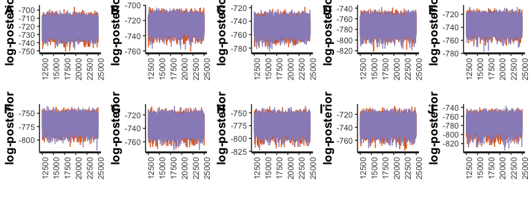

```r
plot_lp <- function(fit) {
  pl <- rstan::traceplot(fit, pars = "lp__")
  no_leg_pl <- pl + theme(legend.position = "none",
                          axis.text.x = element_text(angle = 90))
  return(no_leg_pl)
}

trace_plots <- lapply(fit_list, plot_lp)

(strain_and_serotype_trace_plots <-
  cowplot::plot_grid(plotlist = trace_plots, ncol = 5, nrow = 2, labels = "AUTO")
)
```

```r
ggsave(strain_and_serotype_trace_plots,
       file = "strain_and_serotype_trace_plots.png",
       width = 11,
       height = 7
)
```

## Compare model observations and predictions

For each model, the output can be processed, and the observations plotted against each model’s predictions.

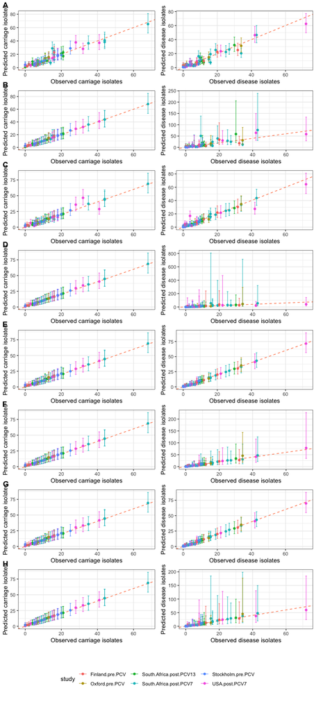

```r
model_outputs <- list(
  adjusted_serotype_specific_poisson_output_df,
  adjusted_serotype_specific_negbin_output_df,
  adjusted_strain_specific_poisson_output_df,
  adjusted_strain_specific_negbin_output_df,
  adjusted_serotype_specific_strain_modified_poisson_output_df,
  adjusted_serotype_specific_strain_modified_negbin_output_df,
  adjusted_strain_specific_serotype_modified_poisson_output_df,
  adjusted_strain_specific_serotype_modified_negbin_output_df,
  adjusted_strain_and_serotype_specific_poisson_output_df,
  adjusted_strain_and_serotype_specific_negbin_output_df
)

label_list <- list(
  "type",
  "type",
  "type",
  "type",
  "type",
  "type",
  "type",
  "type",
  "combined",
  "combined"
)

prediction_plots <- list()
for (i in 1:length(model_outputs)) {
  prediction_plots[[i]] <- progressionEstimation::plot_case_carrier_predictions(
                                                       model_outputs[[i]],
                                                       label_col = label_list[[i]],
                                                       legend = FALSE,
                                                       n_label = 0)
}

no_leg_plot <- cowplot::plot_grid(plotlist = prediction_plots,
                                  ncol = 1,
                                  nrow = 8,
                                  labels = "AUTO",
                                  vjust = -0.01) +
      theme(plot.margin = unit(c(0.5,0,0,0), "cm"))

prediction_plot_legend <- progressionEstimation::plot_case_carrier_predictions(model_outputs[[1]], just_legend = TRUE)

(pred_v_obs_plot <-
  cowplot::plot_grid(no_leg_plot,
                     prediction_plot_legend,
                     ncol = 1,
                     rel_heights = c(1,0.1)))
```

```r
ggsave(pred_v_obs_plot,
       file = "infant_strain_serotypes_pred_v_obs_plot.png",
       height = 20,
       width = 10)
```

The deviation of the predicted and observed values can be simply evaluated using the root mean square error:

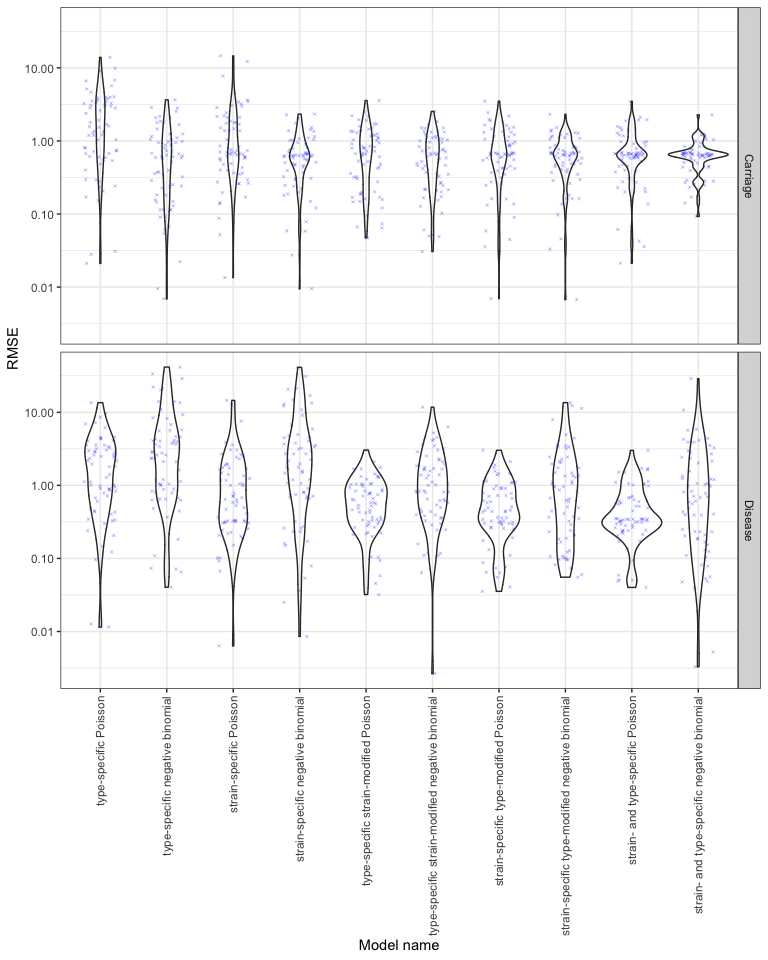

```r
obs_pred_df <-
  dplyr::bind_rows(model_outputs) %>%
  dplyr::select(model_name,carriage_rmse,disease_rmse,phi,phi_lower,phi_upper) %>%
  tidyr::pivot_longer(c(carriage_rmse,disease_rmse), names_to = "Observation", values_to = "RMSE") %>%
  dplyr::mutate(model_name = factor(model_name,
                                    levels = c(
                                      "serotype_specific_poisson",
                                      "serotype_specific_negbin",
                                      "strain_specific_poisson",
                                      "strain_specific_negbin",
                                      "serotype_specific_strain_modified_poisson",
                                      "serotype_specific_strain_modified_negbin",
                                      "strain_specific_serotype_modified_poisson",
                                      "strain_specific_serotype_modified_negbin",
                                      "strain_and_serotype_specific_poisson",
                                      "strain_and_serotype_specific_negbin"
                                      )
                                    )
                ) %>%
  dplyr::mutate(Observation = dplyr::case_when(
                    Observation == "carriage_rmse" ~ "Carriage",
                    Observation == "disease_rmse" ~ "Disease"
                  )
                )

(strain_and_serotype_rmse_plot <-
  ggplot(obs_pred_df, aes(x = model_name, y = RMSE)) +
    geom_point(position = position_jitter(width = 0.25),
               alpha = 0.25,
               cex = 0.75,
               colour = "blue",
               pch = 4) +
    geom_violin(fill = NA) +
    scale_y_continuous(trans="log10") +
    xlab("Model name") +
    scale_x_discrete(labels = model_name_labels) +
    theme_bw() +
    facet_grid(Observation ~ .) +
    theme(axis.text.x = element_text(angle = 90, vjust = 0.5, hjust = 1))
)
```

```r
ggsave(strain_and_serotype_rmse_plot,
       file = "strain_and_serotype_rmse_plot.png",
       width = 7,
       height = 7
)
```

The fits of the negative binomial can be evaluated through plotting the estimates of the precision parameter, $\phi$. As $\phi$ increases, the variance of the negative binomial distribution decreases, and the negative binomal model becomes more similar to the Poisson model.

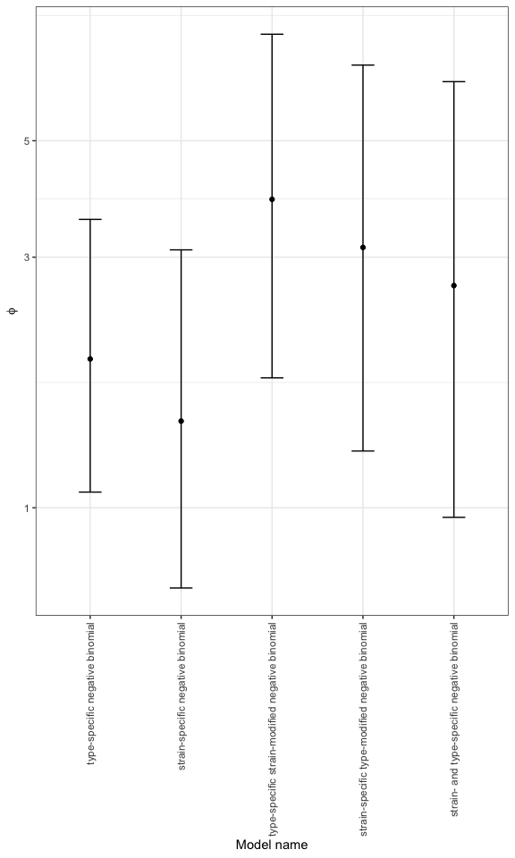

```r
(strain_and_serotype_precision_parameters <-
  ggplot(obs_pred_df %>%
          dplyr::filter(!is.na(phi)) %>%
          dplyr::group_by(model_name) %>%
          dplyr::slice(1) %>%
          dplyr::ungroup(),
        aes(x = model_name,
            y = phi,
            ymin = phi_lower,
            ymax = phi_upper)) +
    geom_point() +
    geom_errorbar(width = 0.25) +
    theme_bw() +
    scale_y_continuous(trans="log10") +
    ylab(expression(phi)) +
    xlab("Model name") +
    scale_x_discrete(labels = model_name_labels[c(2,4,6,8,10)]) +
    theme(axis.text.x = element_text(angle = 90, vjust = 0.5, hjust = 1))
)
```

```r
ggsave(strain_and_serotype_precision_parameters,
       file = "strain_and_serotype_precision_plot.png",
       width = 6,
       height = 6
)
```

## Plot secondary invasiveness for modified invasiveness models

To check these are not being constrained by the prior limits, we plot the invasiveness modification values, first for the type-specific strain-modified Poisson model:

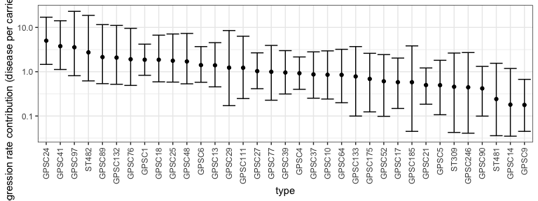

```r
order_strains <-
  model_outputs[[5]] %>%
    dplyr::select(strain,secondary_nu) %>%
    dplyr::distinct() %>%
    dplyr::arrange(desc(secondary_nu)) %>%
    dplyr::select(strain) %>%
    dplyr::mutate(strain = as.character(strain)) %>%
    dplyr::pull()

(strain_inv <-
  progressionEstimation::plot_progression_rates(model_outputs[[5]] %>%
                                                  dplyr::mutate(strain = factor(strain,
                                                                                levels = order_strains)),
                                                type = "strain"))
```

```r
ggsave(strain_inv,
       file = "type_specific_strain_modified_strain_invasiveness.png",
       width = 8,
       height = 6)
```

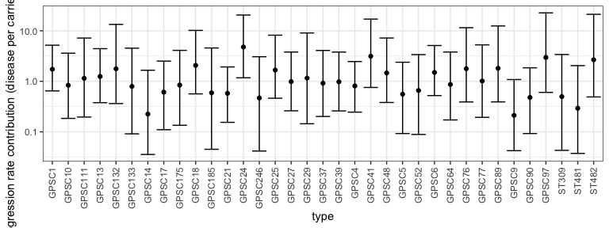

```r
progressionEstimation::plot_progression_rates(model_outputs[[6]], type = "strain")
```

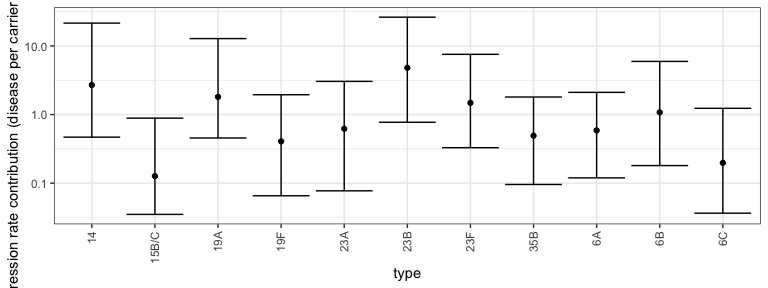

```r
progressionEstimation::plot_progression_rates(model_outputs[[7]])
```

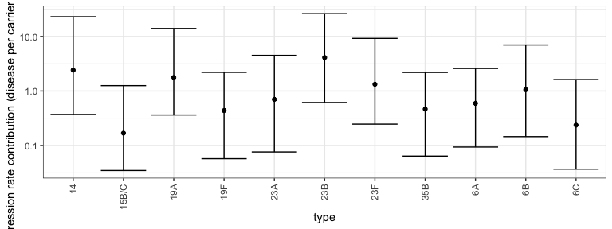

```r
progressionEstimation::plot_progression_rates(model_outputs[[8]])
```

## Run model comparison with leave-one-out cross-validation

The model likelihoods can be compared using leave-one-out cross-validation:

```r
loo_comparison <- progressionEstimation::compare_model_fits_with_loo(fit_list,
                                                                     use_moments = FALSE,
                                                                     num_threads = n_core)









loo_comparison %>%
  kableExtra::kable()  %>%
  kableExtra::kable_styling(latex_options = "scale_down")
```

|  | elpd_diff | se_diff | elpd_loo | se_elpd_loo | p_loo | se_p_loo | looic | se_looic |
| --- | --- | --- | --- | --- | --- | --- | --- | --- |
| serotype_specific_strain_modified_poisson | 0.000000 | 0.000000 | -385.2019 | 9.800251 | 94.92273 | 3.092583 | 770.4039 | 19.60050 |
| strain_and_serotype_specific_poisson | -1.555928 | 3.565421 | -386.7579 | 10.780299 | 99.91711 | 3.609332 | 773.5157 | 21.56060 |
| strain_specific_serotype_modified_poisson | -4.769573 | 3.497835 | -389.9715 | 10.265235 | 101.69951 | 3.628416 | 779.9430 | 20.53047 |
| serotype_specific_strain_modified_negbin | -26.972372 | 3.337377 | -412.1743 | 11.260456 | 91.87327 | 3.011936 | 824.3486 | 22.52091 |
| strain_specific_serotype_modified_negbin | -37.882645 | 4.894518 | -423.0846 | 12.244943 | 100.39207 | 3.504499 | 846.1692 | 24.48989 |
| serotype_specific_negbin | -41.081348 | 5.905017 | -426.2833 | 12.486938 | 81.70653 | 2.927903 | 852.5666 | 24.97388 |
| strain_specific_poisson | -43.612212 | 18.761103 | -428.8142 | 22.254472 | 116.78620 | 11.304089 | 857.6283 | 44.50894 |
| serotype_specific_poisson | -45.209309 | 14.483087 | -430.4113 | 18.829471 | 94.04073 | 6.146281 | 860.8225 | 37.65894 |
| strain_and_serotype_specific_negbin | -48.226987 | 6.016410 | -433.4289 | 12.750154 | 108.09451 | 3.724335 | 866.8579 | 25.50031 |
| strain_specific_negbin | -61.001578 | 6.806206 | -446.2035 | 13.067118 | 103.22326 | 3.351319 | 892.4070 | 26.13424 |

```r
write.csv(loo_comparison,
          file = "child_strain_loo_comparison.csv",
          quote = FALSE,
          row.names = TRUE)
```

The Pareto distribution k values are too high for robust estimates of the ELPD. This reflects there being too few observations per parameter for this type of evaluation. Even usingt the disease likelihoods, we cannot calculate an accuraste cross-validation:

```r
disease_loo_comparison <- progressionEstimation::compare_model_fits_with_loo(fit_list,
                                                                     log_lik_param = "disease_log_lik",
                                                                     use_moments = FALSE,
                                                                     num_threads = n_core)









disease_loo_comparison %>%
  kableExtra::kable()  %>%
  kableExtra::kable_styling(latex_options = "scale_down")
```

|  | elpd_diff | se_diff | elpd_loo | se_elpd_loo | p_loo | se_p_loo | looic | se_looic |
| --- | --- | --- | --- | --- | --- | --- | --- | --- |
| serotype_specific_strain_modified_poisson | 0.0000000 | 0.000000 | -175.2046 | 8.394341 | 43.54962 | 3.167350 | 350.4093 | 16.78868 |
| strain_and_serotype_specific_poisson | -0.5731933 | 2.656717 | -175.7778 | 9.143976 | 46.12602 | 3.392953 | 351.5556 | 18.28795 |
| strain_specific_serotype_modified_poisson | -3.2917825 | 2.344296 | -178.4964 | 9.074371 | 47.91023 | 3.576116 | 356.9928 | 18.14874 |
| serotype_specific_strain_modified_negbin | -21.1370237 | 2.476542 | -196.3416 | 10.043093 | 33.30378 | 2.547575 | 392.6833 | 20.08619 |
| serotype_specific_negbin | -32.0800347 | 5.135090 | -207.2847 | 11.417514 | 23.49981 | 3.525347 | 414.5693 | 22.83503 |
| strain_specific_serotype_modified_negbin | -32.9355456 | 4.169784 | -208.1402 | 10.986727 | 41.67588 | 3.200970 | 416.2803 | 21.97345 |
| strain_specific_poisson | -36.8465948 | 15.833223 | -212.0512 | 18.073692 | 68.13592 | 10.971619 | 424.1024 | 36.14738 |
| strain_and_serotype_specific_negbin | -41.1717194 | 5.350614 | -216.3763 | 11.894632 | 46.81588 | 3.660288 | 432.7527 | 23.78926 |
| serotype_specific_poisson | -44.0438459 | 13.049183 | -219.2485 | 16.692722 | 67.38613 | 9.936623 | 438.4969 | 33.38544 |
| strain_specific_negbin | -51.2781587 | 5.626094 | -226.4828 | 11.745446 | 40.11151 | 3.118328 | 452.9656 | 23.49089 |

```r
write.csv(disease_loo_comparison,
          file = "child_strain_disease_loo_comparison.csv",
          quote = FALSE,
          row.names = TRUE)
```

## Run model comparison with Bayes factors

As the models can instead be compared with Bayes factors:

```r
bf_comparison <- progressionEstimation::compare_model_fits_with_bf(fit_list,
                                                                   num_iter = n_iter,
                                                                   num_threads = n_core)
bf_comparison %>%
  kableExtra::kable()  %>%
  kableExtra::kable_styling(latex_options = "scale_down")
```

| Model | log_Bayes_factor |
| --- | --- |
| serotype_specific_strain_modified_poisson | 0.000000 |
| serotype_specific_negbin | -5.593207 |
| serotype_specific_strain_modified_negbin | -5.985671 |
| serotype_specific_poisson | -24.607137 |
| strain_specific_serotype_modified_poisson | -25.268827 |
| strain_specific_serotype_modified_negbin | -29.979446 |
| strain_and_serotype_specific_poisson | -33.292019 |
| strain_specific_negbin | -33.940225 |
| strain_and_serotype_specific_negbin | -37.325861 |
| strain_specific_poisson | -49.461642 |

```r
write.csv(bf_comparison,
          file = "child_strain_bf_comparison.csv",
          quote = FALSE,
          row.names = FALSE)
```

## Plot serotype invasiveness

The best-fitting model can then be applied to the overall dataset.

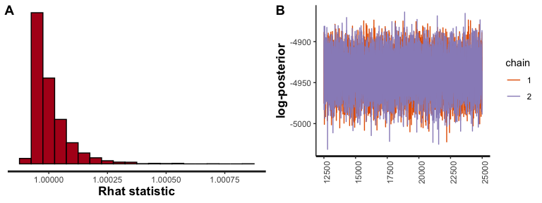

```r
# Generate input for strain and serotype models
full_infant_serotype_and_strain_invasiveness <-
  progressionEstimation::process_input_data(S_pneumoniae_infant_strain,
                                            use_strain = TRUE,
                                            condense = FALSE)

full_adjusted_serotype_specific_strain_modified_poisson_fit <-
  progressionEstimation::fit_progression_rate_model(full_infant_serotype_and_strain_invasiveness,
                                                    type_specific = TRUE,
                                                    location_adjustment = TRUE,
                                                    strain_as_secondary_type = TRUE,
                                                    stat_model = "poisson",
                                                    model_description = "serotype_specific_strain_modified_poisson",
                                                    num_chains = n_chains,
                                                    num_iter = n_iter,
                                                    num_cores = n_core,
                                                    adapt_delta_value = adapt_delta,
                                                    stepsize_value = stepsize,
                                                    max_treedepth_value = max_treedepth)

rhat_plot <- plot(full_adjusted_serotype_specific_strain_modified_poisson_fit,
                  plotfun = "rhat",
                  binwidth = 0.00005)

trace_plot <- rstan::traceplot(full_adjusted_serotype_specific_strain_modified_poisson_fit,
                               pars = "lp__") +
              theme(axis.text.x = element_text(angle = 90))

(full_strain_and_serotype_validation_plot <-
  cowplot::plot_grid(plotlist = list(rhat_plot,trace_plot),
                     nrow = 1,
                     ncol = 2,
                     labels = "AUTO")
)
```

```r
ggsave(full_strain_and_serotype_validation_plot,
       file = "full_strain_and_serotype_validation_plot.png",
       width = 7,
       height = 5
)
```

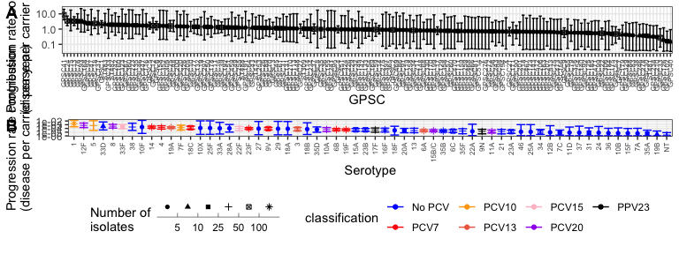

```r
# Annotate serotypes by status
best_fitting_output <-
  progressionEstimation::process_progression_rate_model_output(full_adjusted_serotype_specific_strain_modified_poisson_fit,
                                                               S_pneumoniae_infant_strain,
                                                               strain_as_secondary_type = TRUE,
                                                               condense = FALSE) %>%
    dplyr::mutate("type" = S_pneumoniae_infant_strain$type) %>%
    dplyr::mutate("classification" = dplyr::case_when(
        type %in% vaccine_types[["PCV7"]] ~ "PCV7",
        type %in% vaccine_types[["PCV10"]] ~ "PCV10",
        type %in% vaccine_types[["PCV13"]] ~ "PCV13",
        type %in% vaccine_types[["PCV15"]] ~ "PCV15",
        type %in% vaccine_types[["PCV20"]] ~ "PCV20",
        type %in% vaccine_types[["PPV23"]] ~ "PPV23",
        TRUE ~ "No PCV"
      )
    ) %>%
    dplyr::mutate(classification = factor(classification, levels = c("PCV7",
                                                                     "PCV10",
                                                                     "PCV13",
                                                                     "PCV15",
                                                                     "PCV20",
                                                                     "PPV23",
                                                                     "No PCV"))) %>%
    dplyr::mutate(combined_nu = nu * secondary_nu) %>%
    tidyr::unite(combined,
                 type,strain,
                 sep = "_",
                 remove = FALSE)

# Order serotypes
serotypes_by_invasiveness <-
  best_fitting_output %>%
    dplyr::select(type,nu) %>%
    dplyr::distinct() %>%
    dplyr::arrange(desc(nu)) %>%
    dplyr::select(type) %>%
    dplyr::mutate(type = as.character(type)) %>%
    dplyr::pull()

# Order strains
strains_by_invasiveness <-
  best_fitting_output %>%
    dplyr::select(strain,secondary_nu) %>%
    dplyr::distinct() %>%
    dplyr::arrange(desc(secondary_nu)) %>%
    dplyr::select(strain) %>%
    dplyr::mutate(strain = as.character(strain)) %>%
    dplyr::pull()

best_fitting_output %<>%
  dplyr::mutate(type = factor(type, levels = serotypes_by_invasiveness)) %>%
  dplyr::mutate(strain = factor(strain, levels = strains_by_invasiveness))

# Plot
strain_invasiveness <-
  progressionEstimation::plot_progression_rates(best_fitting_output,
                                                type = "strain",
                                                unit_time = "year",
                                                type_name = "GPSC",
                                                use_sample_size = TRUE) +
    ylab("Progression rate contribution\n(disease per carrier per year)") +
    theme(axis.text.x = element_text(size = 6))

type_invasiveness <-
  progressionEstimation::plot_progression_rates(best_fitting_output,
                                                type = "type",
                                                unit_time = "year",
                                                type_name = "Serotype",
                                                colour_col = "classification",
                                                colour_palette = vaccine_colours,
                                                use_sample_size = TRUE) +
    ylab("Progression rate contribution\n(disease per carrier per year)") +
    theme(axis.text.x = element_text(size = 6))

(joint_invasiveness <-
  cowplot::plot_grid(plotlist = list(strain_invasiveness + theme(legend.position = "none"),
                                     type_invasiveness),
                     labels = "AUTO",
                     nrow = 2,
                     rel_heights = c(1,1.25)))
```

```r
ggsave(joint_invasiveness,
       file = "full_strain_and_serotype_invasiveness_plot.png",
       width = 20,
       height = 10
)
```

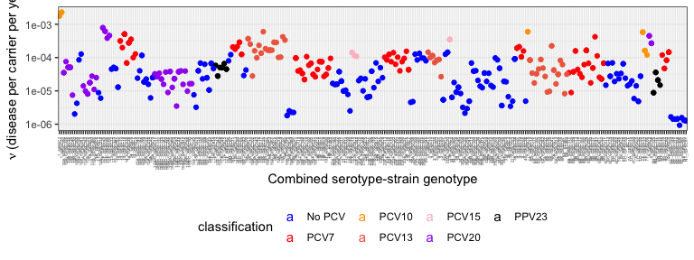

```r
not_in_current_vaccines <- c("No PCV","PPV23","PCV20","PCV15")

(all_combined_invasiveness <-
  ggplot(best_fitting_output %>%
           dplyr::select(combined,combined_nu, classification),
         aes(x = combined,
             y = combined_nu,
             colour = classification,
             label = combined)) +
    geom_point() +
    scale_y_continuous(trans = "log10") +
    ylab(expression(nu~"(disease per carrier per year)")) +
    scale_colour_manual(values = vaccine_colours) +
    xlab("Combined serotype-strain genotype") +
    theme_bw() +
    theme(axis.text.x = element_text(angle = 90,
                                     hjust = 1,
                                     vjust = 0.5,
                                     size = 3.5),
          legend.position = "bottom") +
    ggrepel::geom_label_repel(data = best_fitting_output %>%
                                      dplyr::select(combined,combined_nu, classification) %>%
                                      dplyr::filter(classification %in% not_in_current_vaccines[1:2]) %>%
                                        dplyr::filter(combined_nu > 10**(-3.25)) %>%
                                        dplyr::distinct(),
                              aes(label = combined),
                              force_pull = 0.0,
                              force = 10,
                              direction = "y",
                              size = 4,
                              max.overlaps = 20)
)
```

```r
ggsave(all_combined_invasiveness,
       file = "combined_invasiveness_for_all_genotypes.png",
       width = 11,
       height = 8)
```

## Save overall dataset

```r
write.csv(best_fitting_output %>%
            dplyr::select(combined,type,strain,
                          nu,nu_lower,nu_upper,
                          secondary_nu,secondary_nu_lower,secondary_nu_upper) %>%
            dplyr::rename(genotype = combined) %>%
            dplyr::rename(serotype_invasiveness = nu) %>%
            dplyr::rename(serotype_invasiveness_lower = nu_lower) %>%
            dplyr::rename(serotype_invasiveness_upper = nu_upper) %>%
            dplyr::rename(strain_invasiveness = secondary_nu) %>%
            dplyr::rename(strain_invasiveness_lower = secondary_nu_lower) %>%
            dplyr::rename(strain_invasiveness_upper = secondary_nu_upper) %>%
            dplyr::distinct() %>%
            dplyr::arrange(genotype),
          file = "Dataset_S3.csv",
          quote = F,
          row.names = F)
```

## Filter to only larger sample sizes

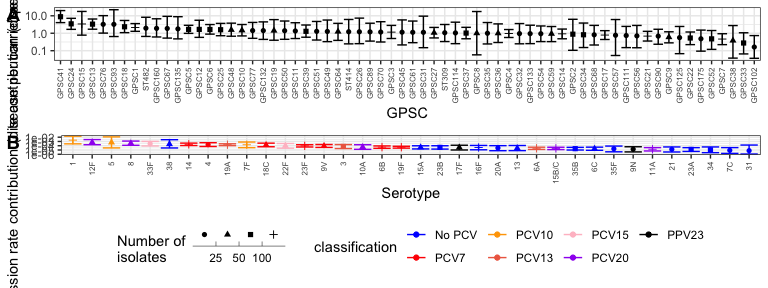

```r
# Annotate sample size
filtered_best_fitting_output <-
  best_fitting_output %>%
    dplyr::group_by(combined) %>%
    dplyr::mutate(num_observations = sum(carriage+disease)) %>%
    dplyr::ungroup() %>%
    dplyr::filter(num_observations >= 10) %>%
    dplyr::group_by(strain) %>%
    dplyr::mutate(num_serotypes = dplyr::n_distinct(type)) %>%
    dplyr::ungroup() %>%
    dplyr::group_by(type) %>%
    dplyr::mutate(num_strains = dplyr::n_distinct(strain)) %>%
    dplyr::ungroup()

# Plot
filtered_strain_invasiveness <-
  progressionEstimation::plot_progression_rates(filtered_best_fitting_output,
                                                type = "strain",
                                                unit_time = "year",
                                                type_name = "GPSC",
                                                use_sample_size = TRUE) +
    theme(axis.text.x = element_text(size = 6))

filtered_type_invasiveness <-
  progressionEstimation::plot_progression_rates(filtered_best_fitting_output,
                                                type = "type",
                                                unit_time = "year",
                                                type_name = "Serotype",
                                                colour_col = "classification",
                                                colour_palette = vaccine_colours,
                                                use_sample_size = TRUE) +
    theme(axis.text.x = element_text(size = 6))

(filtered_joint_invasiveness <-
  cowplot::plot_grid(plotlist = list(filtered_strain_invasiveness + theme(legend.position = "none"),
                                     filtered_type_invasiveness),
                     labels = "AUTO",
                     nrow = 2,
                     rel_heights = c(1,1.25)))
```

```r
ggsave(filtered_joint_invasiveness,
       file = "filtered_full_strain_and_serotype_invasiveness_plot.png",
       width = 20,
       height = 10
)
```

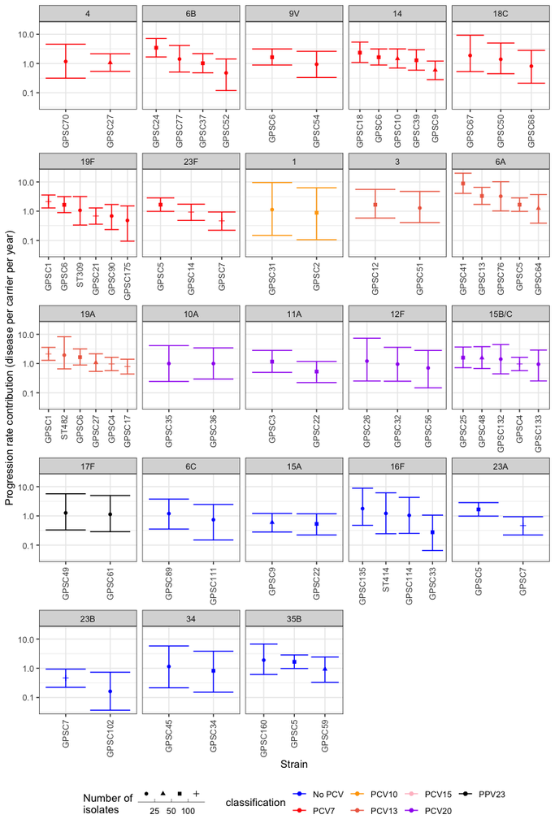

```r
# Function needed if processing combined serotype/strain assignments
mixedrank = function(x) order(gtools::mixedorder(as.character(x)))

# Reorder by serotype
serotype_levels <-
  filtered_best_fitting_output %>%
    dplyr::select(type,classification) %>%
    dplyr::distinct() %>%
    dplyr::group_by(classification) %>%
    dplyr::arrange(mixedrank(type),
                   .by_group = TRUE) %>%
    dplyr::ungroup() %>%
    dplyr::select(type) %>%
    dplyr::mutate(as.character(type)) %>%
    dplyr::pull()

# Reorder by strain
strain_levels <-
  filtered_best_fitting_output %>%
    dplyr::select(strain,secondary_nu) %>%
    dplyr::distinct() %>%
    dplyr::arrange(desc(secondary_nu)) %>%
    dplyr::select(strain) %>%
    dplyr::mutate(as.character(strain)) %>%
    dplyr::pull()

filtered_best_fitting_output %<>%
  dplyr::mutate(strain = factor(strain, levels = strain_levels)) %>%
  dplyr::mutate(type = factor(type, levels = serotype_levels))

(serotype_invasiveness_plot <-
  plot_progression_rate_by_type(filtered_best_fitting_output %>%
                                                  dplyr::filter(num_strains > 1),
                                                type = "strain",
                                                unit_time = "year",
                                                type_name = "Strain",
                                                colour_col = "classification",
                                                colour_palette = vaccine_colours,
                                                use_sample_size = TRUE) +
                                                facet_wrap(.~type,
                                                           scales = 'free_x'))
```

```r
ggsave(serotype_invasiveness_plot,
       file = "within_serotype_invasiveness_variation_plot.png",
       width = 8,
       height = 12
)

ggsave(serotype_invasiveness_plot,
       file = "within_serotype_invasiveness_variation_plot.pdf",
       width = 8,
       height = 12
)
```

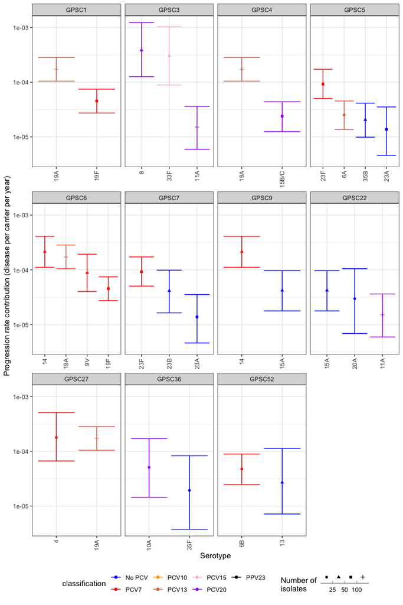

```r
# Reorder by serotype
serotype_levels <-
  filtered_best_fitting_output %>%
    dplyr::select(type,nu) %>%
    dplyr::distinct() %>%
    dplyr::arrange(desc(nu)) %>%
    dplyr::ungroup() %>%
    dplyr::select(type) %>%
    dplyr::mutate(as.character(type)) %>%
    dplyr::pull()

# Reorder by strain
strain_levels <-
  gtools::mixedsort(
    filtered_best_fitting_output %>%
      dplyr::select(strain) %>%
      dplyr::distinct() %>%
      dplyr::mutate(strain = as.character(strain)) %>%
      dplyr::pull()
    )

filtered_best_fitting_output %<>%
  dplyr::mutate(strain = factor(strain, levels = strain_levels)) %>%
  dplyr::mutate(type = factor(type, levels = serotype_levels))

(strain_invasiveness_plot <-
  plot_progression_rate_by_type(filtered_best_fitting_output %>%
                                                    dplyr::filter(num_serotypes > 1),
                                                  type = "type",
                                                  unit_time = "year",
                                                  type_name = "Serotype",
                                                  colour_col = "classification",
                                                  colour_palette = vaccine_colours,
                                                  use_sample_size = TRUE) +
                                                  facet_wrap(.~strain,
                                                             scales = 'free_x')
)
```

```r
ggsave(strain_invasiveness_plot,
       file = "within_strain_invasiveness_variation_plot.png",
       width = 8,
       height = 8
)

ggsave(strain_invasiveness_plot,
       file = "within_strain_invasiveness_variation_plot.pdf",
       width = 8,
       height = 8
)
```

## Plot study-specific scale factors

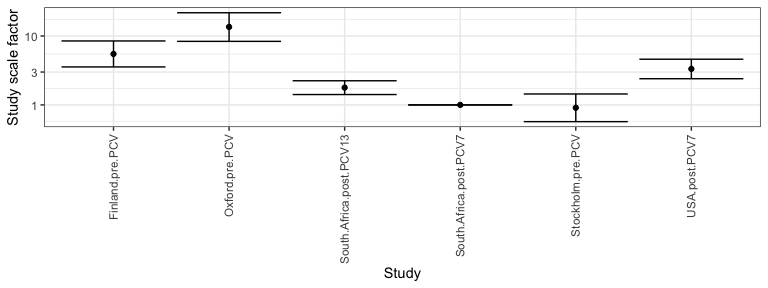

```r
(scale_factor_plot <-
  progressionEstimation::plot_study_scale_factors(best_fitting_output))
```

```r
ggsave(scale_factor_plot,
       file = "full_strain_and_serotype_scale_factor_plot.png",
       width = 6,
       height = 6
)
```

```r
sensitivity_S_pneumoniae_infant_strain <-
  S_pneumoniae_infant_strain %>%
    dplyr::filter(carriage >= threshold_count | disease >= threshold_count) %>%
    dplyr::mutate(carriage_samples = dplyr::case_when(
                      study %in% c("Finland.Pre.PCV","Oxford.pre.PCV","Stockholm.pre.PCV") ~ as.integer(carriage_samples*100),
                      TRUE ~ carriage_samples
                    )
                  ) %>%
    dplyr::group_by(type) %>%
    dplyr::mutate(strain_count = n_distinct(strain)) %>%
    dplyr::ungroup() %>%
    dplyr::group_by(strain) %>%
    dplyr::mutate(type_count = n_distinct(type)) %>%
    dplyr::ungroup() %>%
    dplyr::filter(strain_count >= threshold_count | type_count >= threshold_count)

sensitivity_S_pneumoniae_infant_strain %<>%
    dplyr::mutate(study = factor(study, levels = studies_by_size[studies_by_size %in% unique(sensitivity_S_pneumoniae_infant_strain$study)]))

sensitivity_S_pneumoniae_infant_strain %<>%
    dplyr::mutate(type = factor(type,
                                          levels = serotype_by_count[serotype_by_count %in% unique(sensitivity_S_pneumoniae_infant_strain$type)])) %>%
  dplyr::mutate(strain = factor(strain))

# Generate input for serotype models
sensitivity_infant_serotype_invasiveness <-
  progressionEstimation::process_input_data(sensitivity_S_pneumoniae_infant_strain,
                                            condense = FALSE)

# Generate input for strain models
sensitivity_infant_strain_invasiveness <-
  progressionEstimation::process_input_data(sensitivity_S_pneumoniae_infant_strain,
                                            type = "strain",
                                            condense = FALSE)

# Generate input for strain and serotype models
sensitivity_infant_serotype_and_strain_invasiveness <-
  progressionEstimation::process_input_data(sensitivity_S_pneumoniae_infant_strain,
                                            use_strain = TRUE,
                                            condense = FALSE)

# Generate input for serotype models
sensitivity_infant_serotype_strain_combined_invasiveness <-
  progressionEstimation::process_input_data(sensitivity_S_pneumoniae_infant_strain,
                                            combine_strain = TRUE,
                                            condense = FALSE)
```

Fit the first model:

```r
sensitivity_adjusted_serotype_specific_poisson_fit <-
  progressionEstimation::fit_progression_rate_model(sensitivity_infant_serotype_invasiveness,
                                                    type_specific = TRUE,
                                                    location_adjustment = TRUE,
                                                    stat_model = "poisson",
                                                    model_description = "serotype_specific_poisson",
                                                    num_chains = n_chains,
                                                    num_iter = n_iter,
                                                    num_cores = n_core,
                                                    adapt_delta_value = adapt_delta,
                                                    stepsize_value = stepsize,
                                                    max_treedepth_value = max_treedepth)

sensitivity_adjusted_serotype_specific_poisson_output_df <-
  progressionEstimation::process_progression_rate_model_output(sensitivity_adjusted_serotype_specific_poisson_fit,
                                                               sensitivity_S_pneumoniae_infant_strain,
                                                               condense = FALSE)
```

```r
sensitivity_fit_list <- list(
  sensitivity_adjusted_serotype_specific_poisson_fit,
  sensitivity_adjusted_serotype_specific_negbin_fit,
  sensitivity_adjusted_strain_specific_poisson_fit,
  sensitivity_adjusted_strain_specific_negbin_fit,
  sensitivity_adjusted_serotype_specific_strain_modified_poisson_fit,
  sensitivity_adjusted_strain_specific_strain_modified_negbin_fit,
  sensitivity_adjusted_strain_specific_serotype_modified_poisson_fit,
  sensitivity_adjusted_strain_specific_serotype_modified_negbin_fit,
  sensitivity_adjusted_strain_and_serotype_specific_poisson_fit,
  sensitivity_adjusted_strain_and_serotype_specific_negbin_fit
)

sensitivity_bf_comparison <-
  progressionEstimation::compare_model_fits_with_bf(
                                                    sensitivity_fit_list,
                                                    num_iter = n_iter,
                                                    num_threads = n_core)

sensitivity_bf_comparison %>%
  kableExtra::kable()  %>%
  kableExtra::kable_styling(latex_options = "scale_down")
```

| Model | log_Bayes_factor |
| --- | --- |
| serotype_specific_strain_modified_poisson | 0.000000 |
| serotype_specific_negbin | -5.627929 |
| serotype_specific_strain_modified_negbin | -5.940804 |
| serotype_specific_poisson | -24.704099 |
| strain_specific_serotype_modified_poisson | -25.281506 |
| strain_specific_serotype_modified_negbin | -29.671881 |
| strain_and_serotype_specific_poisson | -32.859631 |
| strain_specific_negbin | -33.488613 |
| strain_and_serotype_specific_negbin | -36.481845 |
| strain_specific_poisson | -49.395688 |

```r
write.csv(bf_comparison,
          file = "child_strain_bf_sensitivity_comparison.csv",
          quote = FALSE,
          row.names = FALSE)
```